# Machine Learning - Prediction Assignment

Luis Oliveira

23/08/2020

# 1. Introduction

This project was made for the Machine Learning course, which is part of the Data Science Specialization.

Using devices such as Jawbone Up, Nike FuelBand, and Fitbit it is now possible to collect a large amount of data about personal activity relatively inexpensively. These type of devices are part of the quantified self movement – a group of enthusiasts who take measurements about themselves regularly to improve their health, to find patterns in their behavior, or because they are tech geeks. One thing that people regularly do is quantify how much of a particular activity they do, but they rarely quantify how well they do it. In this project, the goal will be to use data from accelerometers on the belt, forearm, arm, and dumbell of 6 participants. They were asked to perform barbell lifts correctly and incorrectly in 5 different ways. More information is available from the website here:

http://web.archive.org/web/20161224072740/

http:/groupware.les.inf.puc-rio.br/har (see the section on the Weight Lifting Exercise Dataset).

# 2. Data used in the project

The training data for this project are available here:

https://d396qusza40orc.cloudfront.net/predmachlearn/pml-training.csv

The test data are available here:

https://d396qusza40orc.cloudfront.net/predmachlearn/pml-testing.csv

The data for this project come from this source: http://web.archive.org/web/20161224072740/http:/groupware.les.inf.puc-rio.br/har

# 3. Preparing R environment loading libraries needed

```r
library(lattice)
library(ggplot2)
library(caret)
library(rpart)
library(rpart.plot)
library(corrplot)
library(rattle)
library(randomForest)
library(RColorBrewer)
```

# 4. Loading and preparing the dataset

```r
data_train <- read.csv('pml-training.csv', header=T)
data_quiz <- read.csv('pml-testing.csv', header=T)
```

## Dimension of original data

```r
dim(data_train)
```

```
## [1] 19622   160
```

```r
dim(data_quiz)
```

```
## [1]  20 160
```

## Data partion for estimation and prediction

```r
in_train  <- createDataPartition(data_train$classe, p=0.75, list=FALSE)
train_set <- data_train[ in_train, ]
test_set  <- data_train[-in_train, ]

dim(train_set)
```

```
## [1] 14718   160
```

```r
dim(test_set)
```

```
## [1] 4904  160
```

## Cleaning data from NA values

```r
nzv_var <- nearZeroVar(train_set)

train_set <- train_set[ , -nzv_var]
test_set  <- test_set [ , -nzv_var]
```

## Dimension of ajusted data

```r
dim(train_set)
```

```
## [1] 14718   100
```

```r
dim(test_set)
```

```
## [1] 4904  100
```

## Cleaning variables close to NA

```r
na_var <- sapply(train_set, function(x) mean(is.na(x))) > 0.95
train_set <- train_set[ , na_var == FALSE]
test_set  <- test_set [ , na_var == FALSE]

dim(train_set)
```

```
## [1] 14718    59
```

```r
dim(test_set)
```

```
## [1] 4904   59
```

## Removing identification variables

```r
train_set <- train_set[ , -(1:5)]
test_set  <- test_set [ , -(1:5)]

dim(train_set)
```

```
## [1] 14718    54
```

```r
dim(test_set)
```

```
## [1] 4904   54
```

The number of variables to be used in the analysis was reduced from the 160 to 54.

# 5. Prediction Models

## 5.1. Decision Tree Model

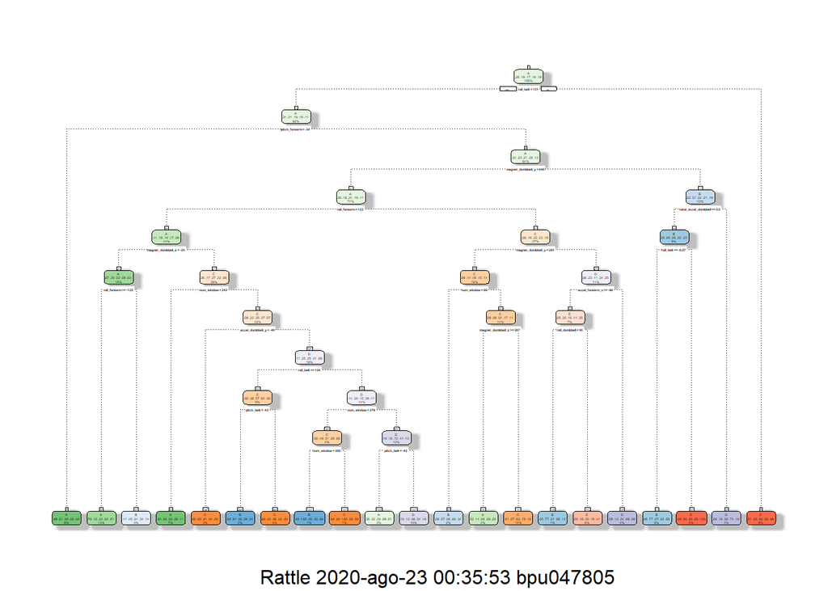

```r
set.seed(1813)
fit_decision_tree <- rpart(classe ~ ., data = train_set, method="class")
fancyRpartPlot(fit_decision_tree)
```

```r
predict_decision_tree <- predict(fit_decision_tree, newdata = test_set, type="class")
conf_matrix_decision_tree <- confusionMatrix(predict_decision_tree, test_set$classe)
conf_matrix_decision_tree
```

```
## Confusion Matrix and Statistics
##
##           Reference
## Prediction    A    B    C    D    E
##          A 1247  188   37   60   61
##          B   47  525   25   62  102
##          C   11   49  684  102   42
##          D   71  127   60  538  104
##          E   19   60   49   42  592
##
## Overall Statistics
##
##                Accuracy : 0.7312
##                  95% CI : (0.7186, 0.7436)
##     No Information Rate : 0.2845
##     P-Value [Acc > NIR] : < 2.2e-16
##
##                   Kappa : 0.6587
##
##  Mcnemar's Test P-Value : < 2.2e-16
##
## Statistics by Class:
##
##                      Class: A Class: B Class: C Class: D Class: E
## Sensitivity            0.8939   0.5532   0.8000   0.6692   0.6570
## Specificity            0.9014   0.9403   0.9496   0.9117   0.9575
## Pos Pred Value         0.7828   0.6899   0.7703   0.5978   0.7769
## Neg Pred Value         0.9553   0.8977   0.9574   0.9336   0.9254
## Prevalence             0.2845   0.1935   0.1743   0.1639   0.1837
## Detection Rate         0.2543   0.1071   0.1395   0.1097   0.1207
## Detection Prevalence   0.3248   0.1552   0.1811   0.1835   0.1554
## Balanced Accuracy      0.8977   0.7468   0.8748   0.7904   0.8073
```

## Decision Tree Model: Predictive Accuracy

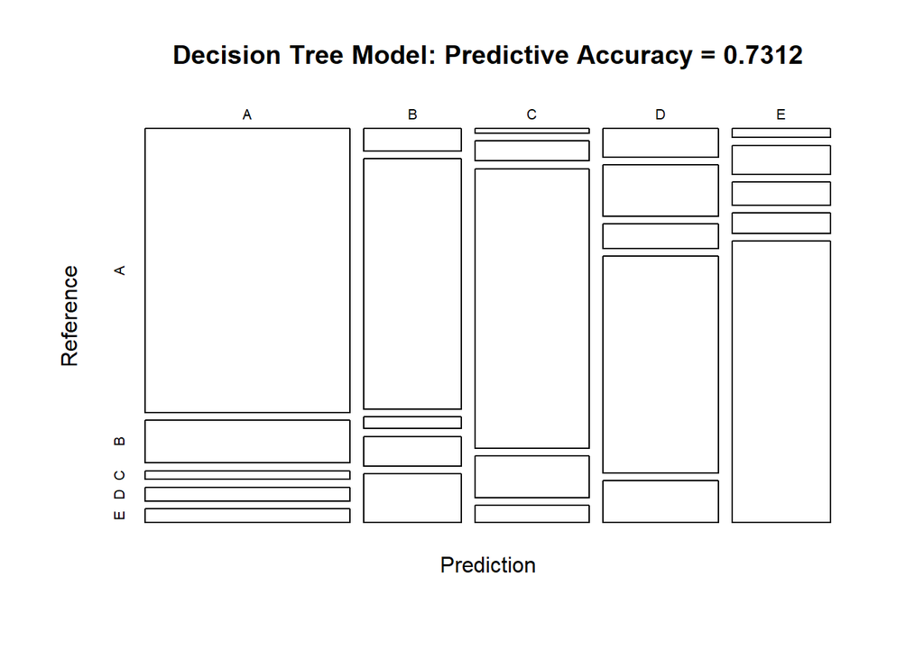

```r
plot(conf_matrix_decision_tree$table, col = conf_matrix_decision_tree$byClass,
     main = paste("Decision Tree Model: Predictive Accuracy =",
                  round(conf_matrix_decision_tree$overall['Accuracy'], 4)))
```

## 5.2 Generalized Boosted Model (GBM)

```r
set.seed(1813)
ctrl_GBM <- trainControl(method = "repeatedcv", number = 5, repeats = 2)
fit_GBM  <- train(classe ~ ., data = train_set, method = "gbm",
                  trControl = ctrl_GBM, verbose = FALSE)
fit_GBM$finalModel
```

```
## A gradient boosted model with multinomial loss function.
## 150 iterations were performed.
## There were 53 predictors of which 52 had non-zero influence.
```

```r
predict_GBM <- predict(fit_GBM, newdata = test_set)
conf_matrix_GBM <- confusionMatrix(predict_GBM, test_set$classe)
conf_matrix_GBM
```

```
## Confusion Matrix and Statistics
##
##           Reference
## Prediction    A    B    C    D    E
##          A 1391    9    0    1    0
##          B    3  928    5    2    2
##          C    0    9  849    8    3
##          D    1    1    1  793    5
##          E    0    2    0    0  891
##
## Overall Statistics
##
##                Accuracy : 0.9894
##                  95% CI : (0.9861, 0.9921)
##     No Information Rate : 0.2845
##     P-Value [Acc > NIR] : < 2.2e-16
##
##                   Kappa : 0.9866
##
##  Mcnemar's Test P-Value : NA
##
## Statistics by Class:
##
##                      Class: A Class: B Class: C Class: D Class: E
## Sensitivity            0.9971   0.9779   0.9930   0.9863   0.9889
## Specificity            0.9972   0.9970   0.9951   0.9980   0.9995
## Pos Pred Value         0.9929   0.9872   0.9770   0.9900   0.9978
## Neg Pred Value         0.9989   0.9947   0.9985   0.9973   0.9975
## Prevalence             0.2845   0.1935   0.1743   0.1639   0.1837
## Detection Rate         0.2836   0.1892   0.1731   0.1617   0.1817
## Detection Prevalence   0.2857   0.1917   0.1772   0.1633   0.1821
## Balanced Accuracy      0.9971   0.9874   0.9940   0.9922   0.9942
```

# 5.3. Random Forest Model

```r
set.seed(1813)
ctrl_RF <- trainControl(method = "repeatedcv", number = 5, repeats = 2)
fit_RF  <- train(classe ~ ., data = train_set, method = "rf",
                 trControl = ctrl_RF, verbose = FALSE)
fit_RF$finalModel
```

```
##
## Call:
##  randomForest(x = x, y = y, mtry = param$mtry, verbose = FALSE)
##                Type of random forest: classification
##                      Number of trees: 500
## No. of variables tried at each split: 27
##
##         OOB estimate of  error rate: 0.2%
## Confusion matrix:
##      A    B    C    D    E  class.error
## A 4183    1    0    0    1 0.0004778973
## B    5 2839    3    1    0 0.0031601124
## C    0    5 2561    1    0 0.0023373588
## D    0    0    8 2403    1 0.0037313433
## E    0    0    0    3 2703 0.0011086475
```

```r
predict_RF <- predict(fit_RF, newdata = test_set)
conf_matrix_RF <- confusionMatrix(predict_RF, test_set$classe)
conf_matrix_RF
```

```
## Confusion Matrix and Statistics
##
##           Reference
## Prediction    A    B    C    D    E
##          A 1395    1    0    0    0
##          B    0  947    1    0    0
##          C    0    1  854    6    0
##          D    0    0    0  798    2
##          E    0    0    0    0  899
##
## Overall Statistics
##
##                Accuracy : 0.9978
##                  95% CI : (0.996, 0.9989)
##     No Information Rate : 0.2845
##     P-Value [Acc > NIR] : < 2.2e-16
##
##                   Kappa : 0.9972
##
##  Mcnemar's Test P-Value : NA
##
## Statistics by Class:
##
##                      Class: A Class: B Class: C Class: D Class: E
## Sensitivity            1.0000   0.9979   0.9988   0.9925   0.9978
## Specificity            0.9997   0.9997   0.9983   0.9995   1.0000
## Pos Pred Value         0.9993   0.9989   0.9919   0.9975   1.0000
## Neg Pred Value         1.0000   0.9995   0.9998   0.9985   0.9995
## Prevalence             0.2845   0.1935   0.1743   0.1639   0.1837
## Detection Rate         0.2845   0.1931   0.1741   0.1627   0.1833
## Detection Prevalence   0.2847   0.1933   0.1756   0.1631   0.1833
## Balanced Accuracy      0.9999   0.9988   0.9986   0.9960   0.9989
```

Predictive accuracy of the Random Forest model: 99.7 %.

# 6. Using the most accurate model to predict the quiz

The best model according to the predictive accuracy is the: Random Forest Model: 99.7%

# Answers to the quiz

The outcome results from the use of the Random Forest model to make predictions on the 20 data points from the original testing dataset.

```r
predict_quiz <- predict(fit_RF, newdata = data_quiz)
predict_quiz
```

```
##  [1] B A B A A E D B A A B C B A E E A B B B
## Levels: A B C D E
```